# Seldin Report: Ssec QQ Plots

Angela Yoder

2022-05-10

**The goals of this program are:**

1. Calculate Ssec scores for Secreted and Non-Secreted proteins v. full datasets
1. Plot Ssec scores in a QQ plot
2. Calculate Ssec scores for Tissue-Exclusive Secreted and Tissue-Exclusive Non-Secreted proteins v. full datasets
2. Plot Ssec scores in a QQ plot

Following the procedure laid out in Seldin, we are comparing secreted proteins to non-secreted proteins from the origin tissue, without the designation of tissue-specific. This was compared to the full protein-coding dataset for the target tissue.

### Secreted v. Non-Secreted

Below are the QQ plots for the Ssec values comparing secreted to non-secreted. Ideally, Ssec values would have higher values in secreted proteins, showing that the Ssec measure was quantifying communication between tissues. However, the graphs show the opposite, with non-secreted proteins having higher correlations to the target tissue proteins than the secreted proteins.

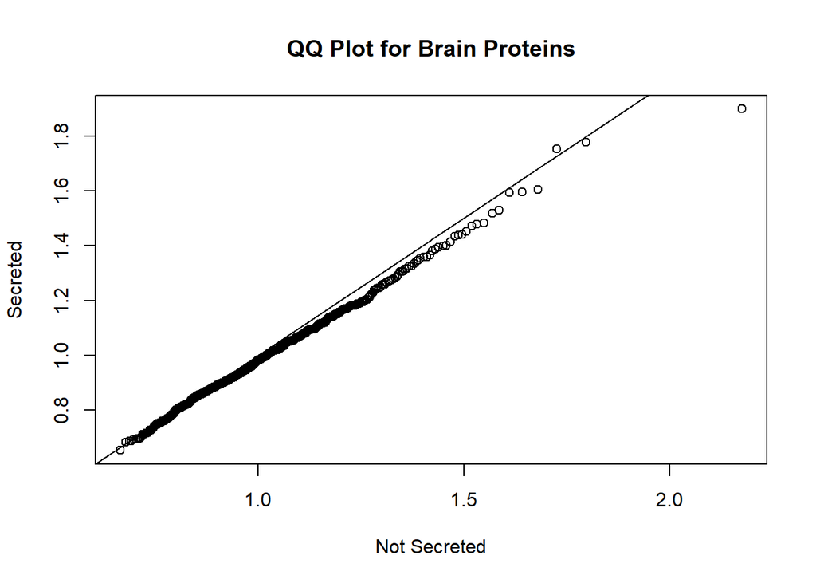

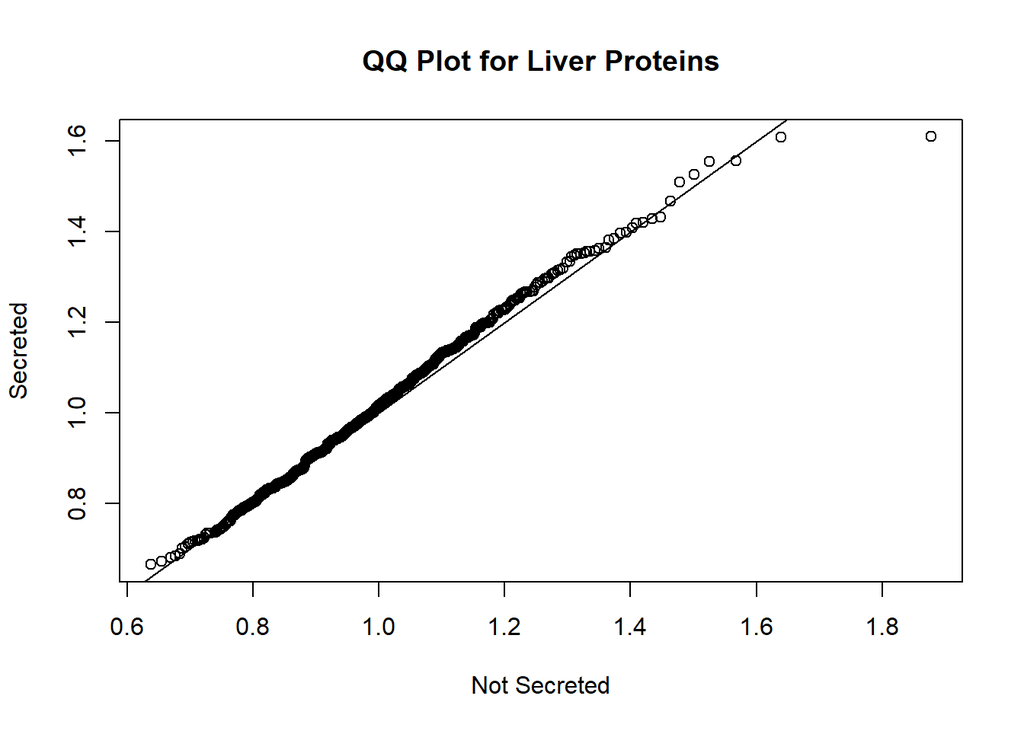

We can confirm by looking at the maximum values for each designation.

Top Ssec Scores by Category

| Secreted Brain | 1.897984 | 1.776545 | 1.752576 | 1.603663 | 1.596532 | 1.593050 |
| --- | --- | --- | --- | --- | --- | --- |
| Non-Secreted Brain | 2.176147 | 2.128371 | 2.119603 | 2.111582 | 2.095682 | 2.055842 |
| Secreted Liver | 1.608791 | 1.607476 | 1.555879 | 1.554776 | 1.524665 | 1.508262 |
| Non-Secreted Liver | 1.877573 | 1.817451 | 1.789856 | 1.760954 | 1.758493 | 1.755927 |

### Tissue-Exclusive Secreted v. Tissue-Exclusive Non-Secreted

Below is the same procedure, but with only RNA sequences that are exclusive to the tissue of interest. Liver appears to favor secreted proteins a bit more, albeit with a much lower sample size. Brain, however, still favors non-secreted protein associations. We can try to repeat this procedure, changing target genes to also be tissue-exclusive, instead of all protein-coding genes.

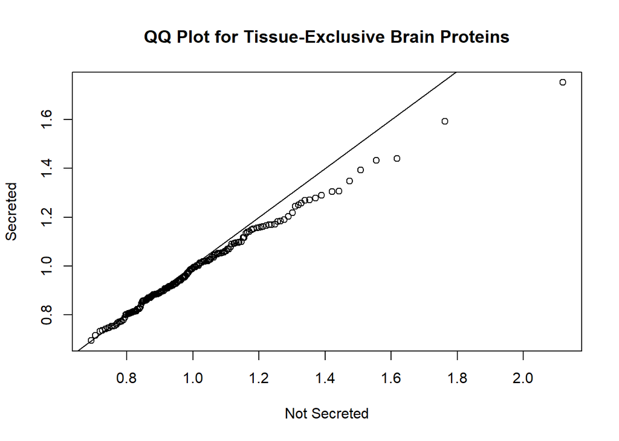

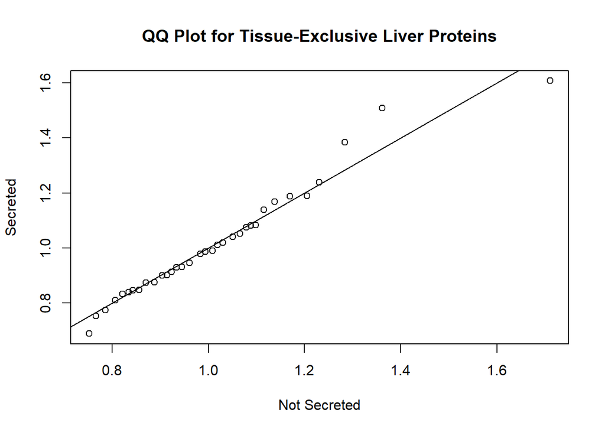

```r
setwd("C:/Users/yodeange/OneDrive - The University of Colorado Denver/Saba Lab/Data")
associate_brain = read.csv("Associations_Brain.csv")
associate_liver = read.csv("Associations_Liver.csv")

top_brain = head(te.sec_Ssec_brain[,1])
bot_brain = tail(te.sec_Ssec_brain[,1])

assoc_top_brain = associate_brain[associate_brain$Var1 %in% top_brain,]
top_assoc_top_brain = assoc_top_brain[assoc_top_brain$value < 0.05,]
one = top_assoc_top_brain[top_assoc_top_brain$Var1 == top_brain[1],]

top_liver = head(te.sec_Ssec_liver[,1])
bot_liver = tail(te.sec_Ssec_liver[,1])

setwd("C:/Users/yodeange/OneDrive - The University of Colorado Denver/Saba Lab/Data")
write.csv(one, "OneSecretedProtein_LessThan5Per.csv")
```

### checking target shit

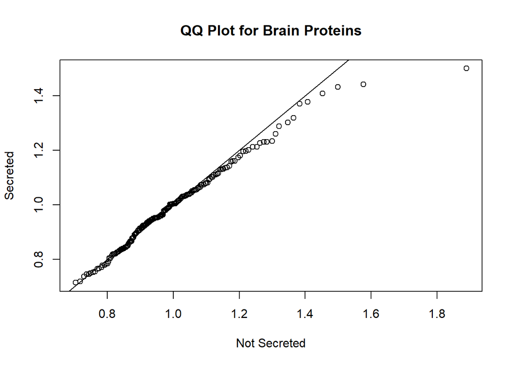

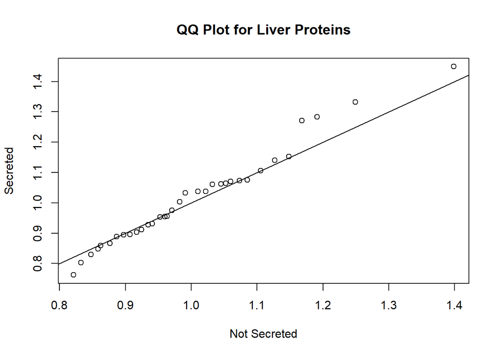